# Компьютерные игры: факторы успеха

# Содержание

## Описание проекта

В данном проекте происходит иссследование факторов, которые влияют на успех компьютерных игр. Исследование проводится для интернет-магазина, выпускающего продукты в этой сфере.

**Основные задачи**:

- выявить определяющие успешность игры закономерности
- выявить черты потенциально популярного продукта в будущем

**План работы**:

- подготовка и исследовательский анализ данных
- описание портрета пользователя каждого региона
- проверка статистических гипотез

**Описание данных**:

В исследовании используются данные из открытых источников за несколько лет: это исторические данные о продажах игр, оценки пользователей и экспертов, жанры и платформы.

## Открытие данных

Импортируем необходимые библиотеки:

```python
import pandas as pd
import os
from matplotlib import pyplot as plt
import seaborn as sns
import matplotlib.gridspec as gridspec
import numpy as np
from scipy import stats as st

import warnings
warnings.filterwarnings("ignore")

import missingno as msno
```

Открываем файл:

```python
if os.path.exists('/datasets/games.csv'):
    df = pd.read_csv('/datasets/games.csv')
else:
    df = pd.read_csv('/C:/datasets/games.csv')
```

Для ознакомления и проверки данных будем использовать собственную функцию:

```python
def my_check_function (dataset):
    '''Функция для ознакомления и проверки даных'''
    print('Размер датасета (количество строк, столбцов):')
    print(dataset.shape)
    print('Как выглядят случайные 5 строк:')
    display(dataset.sample(5, random_state=42))
    print()
    print('Общая информация о данных, наименования столбцов, типы данных:')
    print(dataset.info())
    print()
    print('Есть ли пропуски, сколько их:')
    print(dataset.isna().sum())
    print('Доля пропущенных значений:')
    print(dataset.isna().mean())
    print()
    print('Есть ли явные дубликаты, сколько их:')
    print(dataset.duplicated().sum())
    print('Доля явных дубликатов:')
    print(dataset.duplicated().mean())
    print()
    print('Подробное описание данных:')
    display(dataset.describe())
```

```python
my_check_function(df)
```

```
Размер датасета (количество строк, столбцов):
(16715, 11)
Как выглядят случайные 5 строк:
```

|  | Name | Platform | Year_of_Release | Genre | NA_sales | EU_sales | JP_sales | Other_sales | Critic_Score | User_Score | Rating |
| --- | --- | --- | --- | --- | --- | --- | --- | --- | --- | --- | --- |
| 3485 | London 2012: The Official Video Game of the Ol... | X360 | 2012.0 | Sports | 0.07 | 0.44 | 0.00 | 0.07 | NaN | NaN | NaN |
| 5500 | Etrian Odyssey | DS | 2007.0 | Role-Playing | 0.19 | 0.02 | 0.09 | 0.02 | 75.0 | 8.5 | T |
| 16713 | Spirits & Spells | GBA | 2003.0 | Platform | 0.01 | 0.00 | 0.00 | 0.00 | NaN | NaN | NaN |
| 9489 | RollerCoaster Tycoon | XB | 2003.0 | Strategy | 0.10 | 0.03 | 0.00 | 0.00 | 62.0 | 8.3 | E |
| 12993 | Rhapsody: A Musical Adventure | DS | 2008.0 | Role-Playing | 0.05 | 0.00 | 0.00 | 0.00 | 67.0 | 6.8 | E |

```
Общая информация о данных, наименования столбцов, типы данных:
<class 'pandas.core.frame.DataFrame'>
RangeIndex: 16715 entries, 0 to 16714
Data columns (total 11 columns):
 #   Column           Non-Null Count  Dtype
---  ------           --------------  -----
 0   Name             16713 non-null  object
 1   Platform         16715 non-null  object
 2   Year_of_Release  16446 non-null  float64
 3   Genre            16713 non-null  object
 4   NA_sales         16715 non-null  float64
 5   EU_sales         16715 non-null  float64
 6   JP_sales         16715 non-null  float64
 7   Other_sales      16715 non-null  float64
 8   Critic_Score     8137 non-null   float64
 9   User_Score       10014 non-null  object
 10  Rating           9949 non-null   object
dtypes: float64(6), object(5)
memory usage: 1.4+ MB
None

Есть ли пропуски, сколько их:
Name                  2
Platform              0
Year_of_Release     269
Genre                 2
NA_sales              0
EU_sales              0
JP_sales              0
Other_sales           0
Critic_Score       8578
User_Score         6701
Rating             6766
dtype: int64
Доля пропущенных значений:
Name               0.000120
Platform           0.000000
Year_of_Release    0.016093
Genre              0.000120
NA_sales           0.000000
EU_sales           0.000000
JP_sales           0.000000
Other_sales        0.000000
Critic_Score       0.513192
User_Score         0.400897
Rating             0.404786
dtype: float64

Есть ли явные дубликаты, сколько их:
0
Доля явных дубликатов:
0.0

Подробное описание данных:
```

|  | Year_of_Release | NA_sales | EU_sales | JP_sales | Other_sales | Critic_Score |
| --- | --- | --- | --- | --- | --- | --- |
| count | 16446.000000 | 16715.000000 | 16715.000000 | 16715.000000 | 16715.000000 | 8137.000000 |
| mean | 2006.484616 | 0.263377 | 0.145060 | 0.077617 | 0.047342 | 68.967679 |
| std | 5.877050 | 0.813604 | 0.503339 | 0.308853 | 0.186731 | 13.938165 |
| min | 1980.000000 | 0.000000 | 0.000000 | 0.000000 | 0.000000 | 13.000000 |
| 25% | 2003.000000 | 0.000000 | 0.000000 | 0.000000 | 0.000000 | 60.000000 |
| 50% | 2007.000000 | 0.080000 | 0.020000 | 0.000000 | 0.010000 | 71.000000 |
| 75% | 2010.000000 | 0.240000 | 0.110000 | 0.040000 | 0.030000 | 79.000000 |
| max | 2016.000000 | 41.360000 | 28.960000 | 10.220000 | 10.570000 | 98.000000 |

Поскольку у нас в данных есть много пропусков, мы можем визуализировать их расположение и количество:

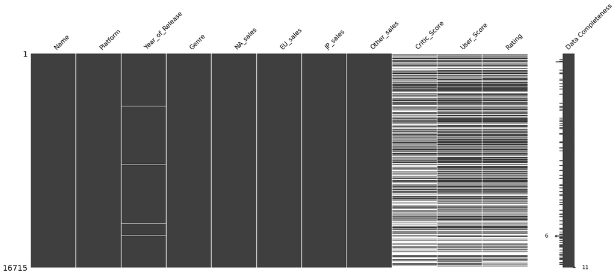

```python
msno.matrix(df, labels=True);
```

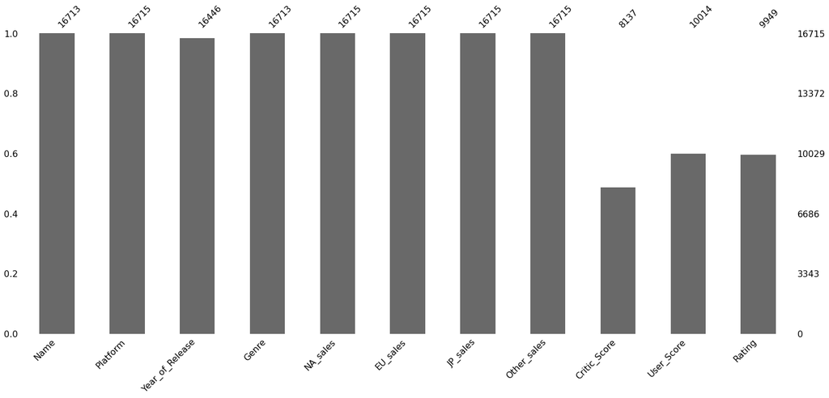

```python
msno.bar(df);
```

### Вывод

- перед нами данные из 16715 строк и 11 столбцов

На что обратить внимание при предобработке:

- стиль написания названий столбцов - привести к нижнему регистру
- столбец user_score - проверить его, преобразовать тип данных
- столбец rating - разобраться с содержимым
- пропуски: выяснить, есть ли возможность их заполнить, разобраться с причинами их появления

## Предобработка и подготовка данных к исследованию

Приведём названия столбцов в нижнему регистру:

```python
df.columns = [x.lower() for x in df.columns]
```

Проверяем:

```python
df.head()
```

|  | name | platform | year_of_release | genre | na_sales | eu_sales | jp_sales | other_sales | critic_score | user_score | rating |
| --- | --- | --- | --- | --- | --- | --- | --- | --- | --- | --- | --- |
| 0 | Wii Sports | Wii | 2006.0 | Sports | 41.36 | 28.96 | 3.77 | 8.45 | 76.0 | 8 | E |
| 1 | Super Mario Bros. | NES | 1985.0 | Platform | 29.08 | 3.58 | 6.81 | 0.77 | NaN | NaN | NaN |
| 2 | Mario Kart Wii | Wii | 2008.0 | Racing | 15.68 | 12.76 | 3.79 | 3.29 | 82.0 | 8.3 | E |
| 3 | Wii Sports Resort | Wii | 2009.0 | Sports | 15.61 | 10.93 | 3.28 | 2.95 | 80.0 | 8 | E |
| 4 | Pokemon Red/Pokemon Blue | GB | 1996.0 | Role-Playing | 11.27 | 8.89 | 10.22 | 1.00 | NaN | NaN | NaN |

Среди столбцов у нас есть один подозрительный момент: user_score имеет формат object, хотя по аналогии с critic_score хотелось бы видеть его в числовом формате. Посмотрим, почему так происходит:

```python
df['user_score'].value_counts()
```

```
tbd    2424
7.8     324
8       290
8.2     282
8.3     254
       ...
1.1       2
1.9       2
9.6       2
0         1
9.7       1
Name: user_score, Length: 96, dtype: int64
```

Кроме чисел здесь имеется аббревиатура tbd: to be determined. Значит, в строках собозначением tbd мы имеем по сути пропуск: пользовательская оценка ещё не определена.

Поскольку это значение помешает нам работать с данными в этом столбце (нам нужен числовой формат), в процессе преобразования удалим его:

```python
df['user_score'] = pd.to_numeric(df['user_score'], errors='coerce')
```

Теперь рассмотрим содержимое столбца rating:

```python
df['rating'].value_counts()
```

```
E       3990
T       2961
M       1563
E10+    1420
EC         8
K-A        3
RP         3
AO         1
Name: rating, dtype: int64
```

Из открытых источников зафиксируем расшифровку:

- «E» («Everyone») — «Для всех». Первоначально "K-A" ("Kids to Adults")
- «T» («Teen») — «Подросткам»
- «M» («Mature») — «Для взрослых»
- «E10+» («Everyone 10 and older»)
- «EC» («Early childhood») — «Для детей младшего возраста»
- «RP» («Rating Pending») — «Рейтинг ожидается»
- «AO» («Adults Only 18+») — «Только для взрослых»

Теперь рассмотрим детальнее пропуски.

```python
df.isna().sum()
```

```
name                  2
platform              0
year_of_release     269
genre                 2
na_sales              0
eu_sales              0
jp_sales              0
other_sales           0
critic_score       8578
user_score         9125
rating             6766
dtype: int64
```

В некоторых столбцах у нас мало пропусков, а в некоторых очень много. Возможно, в первых столбцах (name, year_of_release, genre) пропуски имеют случайный характер, а в последних есть какая-то закономерность и они связаны между собой. Возьмём столбец с наибольшим количеством пропусков (user_score) и визуализируем, насколько пересекаются пропуски.

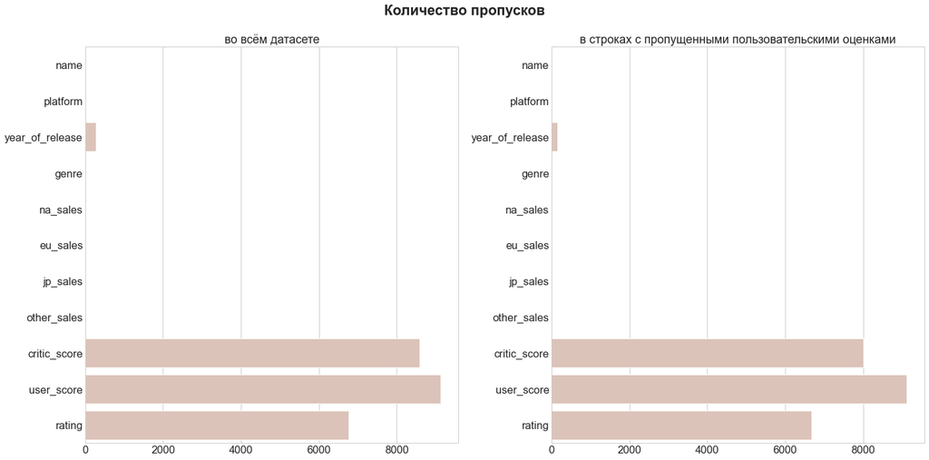

```python
plt.figure(figsize=(20, 10))
sns.set(font_scale=1.5)
plt.style.use('seaborn-whitegrid')
plt.suptitle('Количество пропусков', fontweight='bold')

empty_df = pd.DataFrame(df.isna().sum()).reset_index().rename_axis(None, axis=1)
empty_df.columns=['columns', 'isna_sum']

ax1 = plt.subplot(1, 2, 1)
sns.barplot(data=empty_df, x='isna_sum', y='columns',  color='#e2c1b3')
plt.title('во всём датасете')
plt.xlabel('')
plt.ylabel('')

empty_user_score = pd.DataFrame(df.loc[df['user_score'].isna()].isna().sum()).reset_index().rename_axis(None, axis=1)
empty_user_score.columns=['columns', 'isna_sum']

ax2 = plt.subplot(1, 2, 2)
sns.barplot(data=empty_user_score, x='isna_sum', y='columns',  color='#e2c1b3')
plt.title('в строках с пропущенными пользовательскими оценками')
plt.xlabel('')
plt.ylabel('')

plt.tight_layout()
plt.show();
```

Как мы видим, пропуски сильно пересекаются: те игры, у которых нет пользовательских оценок, очень часто не имеют и оценок от критиков и часто не имеют рейтинга.

Попробуем разобраться с возможными причинами этой ситуации.

**Гипотеза 1**: у игр нет оценок и рейтинга, потому что это не популярные игры. В этом случае мы увидим разницу в *количестве продаж* между играми с оценками и играми без оценок.

**Гипотеза 2**: оценок и рейтинга нет у игр с определённых *платформ*. Если дело в этом, то мы увидим разницу в наименованиях платформ: у игр с оценками будут одни платформы, а у игр без оценок будут другие.

**Гипотеза 3**: дело во *времени выхода* игр. Недавно вышедшие игры ещё не успели получить оценок. В этом случае мы увидим, что игры без оценок имеют недавний год выпуска.

**Гипотеза 4**: *жанр* игры влияет на наличие оценки. В этом случае мы увидим, что у некоторых жанров есть заметная разница в количестве игр с оценками и без.

Добавим в датасет данные о суммарных продажах во всех регионах:

```python
df.head()
```

|  | name | platform | year_of_release | genre | na_sales | eu_sales | jp_sales | other_sales | critic_score | user_score | rating |
| --- | --- | --- | --- | --- | --- | --- | --- | --- | --- | --- | --- |
| 0 | Wii Sports | Wii | 2006.0 | Sports | 41.36 | 28.96 | 3.77 | 8.45 | 76.0 | 8.0 | E |
| 1 | Super Mario Bros. | NES | 1985.0 | Platform | 29.08 | 3.58 | 6.81 | 0.77 | NaN | NaN | NaN |
| 2 | Mario Kart Wii | Wii | 2008.0 | Racing | 15.68 | 12.76 | 3.79 | 3.29 | 82.0 | 8.3 | E |
| 3 | Wii Sports Resort | Wii | 2009.0 | Sports | 15.61 | 10.93 | 3.28 | 2.95 | 80.0 | 8.0 | E |
| 4 | Pokemon Red/Pokemon Blue | GB | 1996.0 | Role-Playing | 11.27 | 8.89 | 10.22 | 1.00 | NaN | NaN | NaN |

```python
df.insert(8, 'total_sales', df['na_sales'] + df['eu_sales'] + df['jp_sales'] + df['other_sales'])
```

Проверим результат:

```python
df.head()
```

|  | name | platform | year_of_release | genre | na_sales | eu_sales | jp_sales | other_sales | total_sales | critic_score | user_score | rating |
| --- | --- | --- | --- | --- | --- | --- | --- | --- | --- | --- | --- | --- |
| 0 | Wii Sports | Wii | 2006.0 | Sports | 41.36 | 28.96 | 3.77 | 8.45 | 82.54 | 76.0 | 8.0 | E |
| 1 | Super Mario Bros. | NES | 1985.0 | Platform | 29.08 | 3.58 | 6.81 | 0.77 | 40.24 | NaN | NaN | NaN |
| 2 | Mario Kart Wii | Wii | 2008.0 | Racing | 15.68 | 12.76 | 3.79 | 3.29 | 35.52 | 82.0 | 8.3 | E |
| 3 | Wii Sports Resort | Wii | 2009.0 | Sports | 15.61 | 10.93 | 3.28 | 2.95 | 32.77 | 80.0 | 8.0 | E |
| 4 | Pokemon Red/Pokemon Blue | GB | 1996.0 | Role-Playing | 11.27 | 8.89 | 10.22 | 1.00 | 31.38 | NaN | NaN | NaN |

Укажем в датасете признак: является ли строка "пустой" или "полной" по наличию пользовательской оценки.

```python
df['full_empty_user_score'] = df['user_score'].apply(lambda x: 'full' if x < 11 else 'empty')
```

Теперь проверим гипотезы. Для удобства визуализируем данные по всем гипотезам на одном графике из нескольких частей:

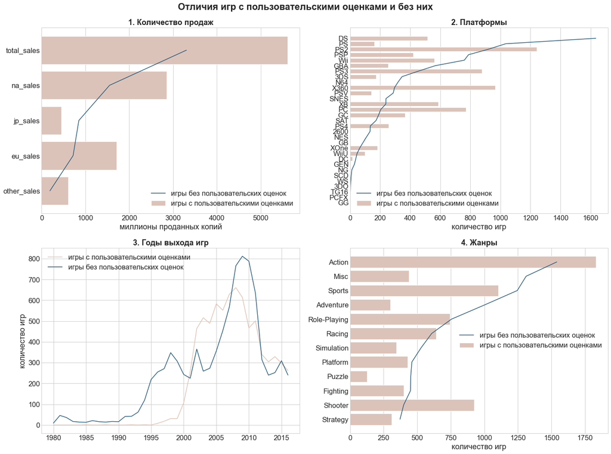

```python
plt.figure(figsize=(20, 15))
sns.set(font_scale=1.5)
plt.style.use('seaborn-whitegrid')
plt.suptitle('Отличия игр с пользовательскими оценками и без них', fontweight='bold')

sales = df[['full_empty_user_score','na_sales','eu_sales', 'jp_sales', 'other_sales', 'total_sales']]
sales = (sales.pivot_table(index='full_empty_user_score', values=sales.columns, aggfunc='sum')
            .T.reset_index().rename_axis(None, axis=1).sort_values(by='empty', ascending=False))
ax1 = plt.subplot(2, 2, 1)
sns.barplot(data=sales, x='full', y='index', ax=ax1, label='игры с пользовательскими оценками', color='#e2c1b3')
sns.lineplot(data=sales, x='empty', y='index', ax=ax1, label='игры без пользовательских оценок', color='#20597b')
plt.title('1. Количество продаж', fontweight='bold')
plt.xlabel('миллионы проданных копий')
plt.ylabel('')

platforms = df[['full_empty_user_score','platform', 'user_score']]
platforms = (platforms.pivot_table(index='platform', values=platforms.columns, aggfunc='count')
                    .reset_index().rename_axis(None, axis=1))
platforms.columns = ['platform', 'total_cnt', 'full_cnt']
platforms['empty_cnt'] = platforms['total_cnt'] - platforms['full_cnt']

ax2 = plt.subplot(2, 2, 2)
sns.barplot(data=platforms.sort_values(by='empty_cnt', ascending=False), y='platform', x='full_cnt', ax=ax2,
               label='игры с пользовательскими оценками', color='#e2c1b3')
sns.lineplot(data=platforms.sort_values(by='empty_cnt', ascending=False), y='platform', x='empty_cnt', ax=ax2,
             label='игры без пользовательских оценок', color='#20597b')
plt.title('2. Платформы', fontweight='bold')
plt.xlabel('количество игр')
plt.ylabel('')

years =  df[['full_empty_user_score','year_of_release', 'user_score']]
years = (years.pivot_table(index='year_of_release', values=years.columns, aggfunc='count')
                    .reset_index().rename_axis(None, axis=1).sort_values(by='year_of_release'))
years.columns = ['year', 'total_cnt', 'full_cnt']
years['empty_cnt'] = years['total_cnt'] - years['full_cnt']
ax3 = plt.subplot(2, 2, 3)
sns.lineplot(data=years, x='year', y='full_cnt', ax=ax3, label='игры с пользовательскими оценками', color='#e2c1b3')
sns.lineplot(data=years, x='year', y='empty_cnt', ax=ax3, label='игры без пользовательских оценок', color='#20597b')
plt.title('3. Годы выхода игр', fontweight='bold')
plt.xlabel('')
plt.ylabel('количество игр')

genres = df[['full_empty_user_score','genre', 'user_score']]
genres = (genres.pivot_table(index='genre', values=genres.columns, aggfunc='count')
            .reset_index().rename_axis(None, axis=1))
genres.columns = ['genre', 'total_cnt', 'full_cnt']
genres['empty_cnt'] = genres['total_cnt'] - genres['full_cnt']
ax4 = plt.subplot(2, 2, 4)
sns.barplot(data=genres.sort_values(by='empty_cnt', ascending=False), y='genre', x='full_cnt', ax=ax4,
               label='игры с пользовательскими оценками', color='#e2c1b3')
sns.lineplot(data=genres.sort_values(by='empty_cnt', ascending=False), y='genre', x='empty_cnt', ax=ax4,
             label='игры без пользовательских оценок', color='#20597b')
plt.title('4. Жанры', fontweight='bold')
plt.xlabel('количество игр')
plt.ylabel('')

plt.tight_layout()
plt.show();
```

Как мы видим, одной-единственной причины отсутствия пользовательских оценок нет, мы можем увидеть связь пропусков с разными факторами:

- *игры без оценок в целом менее популярны* и имеют меньшее количество миллионов проданных копий, чем игры с оценками. Здесь мы видим уверенную закономерность за исключением продаж в Японии. Возможно, пользователи из этого региона менее интегрированы в сообщество игроков всего мира и не всегда знают о сайтах, где можно выставить оценки.
- с платформами смешанная ситуация: у некоторых платформ больше игр с оценками, у других - больше игр без оценок. То есть явной закономерности нет, но некоторые *платформы* вносят свой вклад в наличие пропусков
- игр без оценок больше в ранние *годы*: до 2000 года большая часть игр не имеет оценок, видимо, это связано с тем, что индустрия только развивалась в это время, и не было сайтов, где собирались бы такие оценки. Другой всплеск - 2007-2011 годов, возможно, связан с возросшей конкуренцией - игр уже стало много, и не все могут в этих условиях найти своё место под Солнцем (в душе пользователя).
- только *жанры* Action и Shooter имеют много игр с оценками. В остальном пользователи не особо спешат делиться своим мнением об играх других жанров.

Пропуски заполнять не будем, поскольку это может исказить достоверность наших данных.

### Вывод

В процессе предобработки были выполнены следующие действия:

- названия столбцов приведены к нижнему регистру
- данные в столбце user_score приведены к числовому формату
- записана расшифровка обозначений из столбца rating
- подробно рассмотрены пропуски, разобраны возможные причины их появления, визуализированы отличия игр с оценками и без
- в данные добавлен столбец total_sales - суммарные продажи во всех регионах

## Исследовательский анализ данных

### Сколько игр выпускалось в разные годы

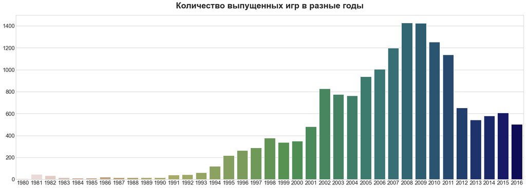

```python
plt.figure(figsize=(27, 9))
sns.set(font_scale=1.5)
plt.style.use('seaborn-whitegrid')

games_by_years = df.groupby('year_of_release').agg({'platform':'count'}).reset_index().rename_axis(None, axis=1)
games_by_years['year_of_release'] = games_by_years['year_of_release'].astype(int)

sns.barplot(data=games_by_years, x='year_of_release', y='platform', palette='gist_earth_r')
plt.title('Количество выпущенных игр в разные годы', fontweight='bold', fontsize=25, pad=20)
plt.xlabel('')
plt.ylabel('')

plt.show();
```

**Вывод**:

- мы видим, что количество выпускаемых игр с годами сильно менялось: плавное увеличение количества игр с середины 1990-х пришло к пику в 2008-2009 годах (когда выходило по 1400 игр в год), и затем сменилось падением. За последнее время рынок стабилизировался на отметке 500-600 выпускаемых игр в год
- для нашего исследования данные 1980-1990х годов не особо актуальны

### Как менялись продажи по платформам

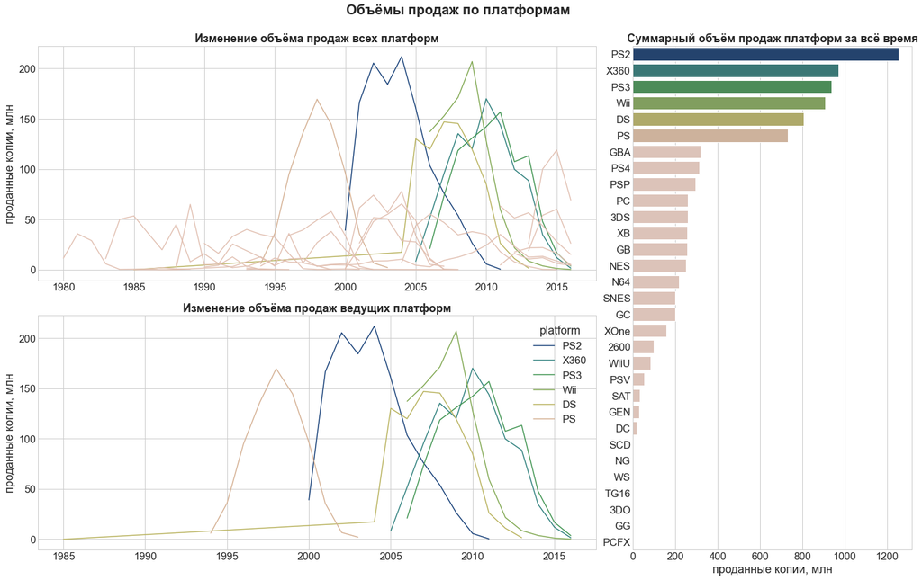

```python
fig = plt.figure(constrained_layout=True, figsize=(20, 12))
sns.set(font_scale=1.5)
plt.style.use('seaborn-whitegrid')
plt.suptitle('Объёмы продаж по платформам', fontweight='bold', y=1.05)
my_palette = ['#184179', '#30817e', '#419552', '#82a954', '#b9b35f', '#d5b194',
              '#e2c1b3','#e2c1b3','#e2c1b3','#e2c1b3','#e2c1b3','#e2c1b3',
              '#e2c1b3','#e2c1b3','#e2c1b3','#e2c1b3','#e2c1b3','#e2c1b3',
              '#e2c1b3','#e2c1b3','#e2c1b3','#e2c1b3','#e2c1b3','#e2c1b3',
              '#e2c1b3','#e2c1b3','#e2c1b3','#e2c1b3','#e2c1b3','#e2c1b3','#e2c1b3']

spec = gridspec.GridSpec(ncols=3, nrows=2, figure=fig)

total_sales_by_platform = (df.groupby('platform').agg({'total_sales':'sum'})
            .reset_index().rename_axis(None, axis=1))


ax1 = fig.add_subplot(spec[0, :-1])
table_1 = (df.groupby(['platform', 'year_of_release']).agg({'total_sales':'sum'}).reset_index().rename_axis(None, axis=1)
               .merge(total_sales_by_platform, on='platform'))

sns.lineplot(data=table_1.sort_values(by='total_sales_y', ascending=False),
             x='year_of_release', y='total_sales_x', hue='platform', palette=my_palette)
plt.title('Изменение объёма продаж всех платформ', fontweight='bold')
plt.xlabel('')
plt.ylabel('проданные копии, млн')
ax1.get_legend().remove()


ax2 = fig.add_subplot(spec[:, -1])
sns.barplot(data=total_sales_by_platform.sort_values(by='total_sales', ascending=False),
            x='total_sales', y='platform', palette=my_palette)
plt.title('Суммарный объём продаж платформ за всё время', fontweight='bold')
plt.xlabel('проданные копии, млн')
plt.ylabel('')

ax3 = fig.add_subplot(spec[1, :-1])
table = total_sales_by_platform.query('total_sales > 400')
platform_names = list(table['platform'])
table_3 = (df.query('platform in @platform_names').groupby(['platform', 'year_of_release'])
            .agg({'total_sales':'sum'}).reset_index().rename_axis(None, axis=1)
            .merge(total_sales_by_platform, on='platform'))

sns.lineplot(data=table_3.sort_values(by='total_sales_y', ascending=False),
             x='year_of_release', y='total_sales_x', hue='platform',
             palette=['#184179', '#30817e', '#419552', '#82a954', '#b9b35f', '#d5b194'])
plt.title('Изменение объёма продаж ведущих платформ', fontweight='bold')
plt.xlabel('')
plt.ylabel('проданные копии, млн')

plt.show()
```

**Вывод**:

- с течением времени разные платформы выходили на первый план по объёмам продаж
- можно отметить *характерный период, за который появляются и исчезают лидеры рынка - это примерно 5 лет*
- при этом отметим, что с 2005 года конкуренция усилилась: если раньше среди крупных платформ был один явный лидер, то теперь успешные платформы существуют параллельно друг с другом, имея сопоставимые объёмы продаж

### Актуальный период и "ящики с усами"

Для того, чтобы заняться прогнозом на следующий год (за теми годами, данные о которых у нас есть), попробуем выделить актуальный период, и отбросить остальные данные.

Посмотрим, как менялись продажи по платформам за последние годы и какие платформы в лидерах за последние годы:

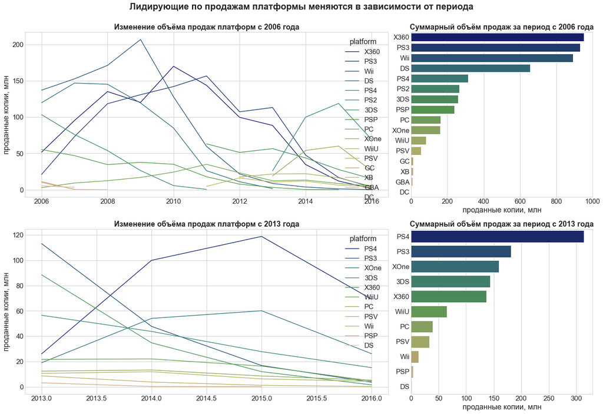

```python
fig = plt.figure(constrained_layout=True, figsize=(20, 13))
sns.set(font_scale=1.5)
plt.style.use('seaborn-whitegrid')
plt.suptitle('Лидирующие по продажам платформы меняются в зависимости от периода', fontweight='bold', y=1.05)
my_palette = 'gist_earth'

spec = gridspec.GridSpec(ncols=3, nrows=2, figure=fig)

total_sales_by_platform_2006 = (df.query('year_of_release > 2005').groupby('platform').agg({'total_sales':'sum'})
                                  .sort_values(by='total_sales', ascending=False)
                                  .reset_index().rename_axis(None, axis=1))

ax1 = fig.add_subplot(spec[0, :-1])
table_1 = (df.query('year_of_release > 2005').groupby(['platform', 'year_of_release']).agg({'total_sales':'sum'})
               .reset_index().rename_axis(None, axis=1)
               .merge(total_sales_by_platform_2006, on='platform'))

sns.lineplot(data=table_1.sort_values(by='total_sales_y', ascending=False),
             x='year_of_release', y='total_sales_x', hue='platform', palette=my_palette)
plt.title('Изменение объёма продаж платформ c 2006 года', fontweight='bold')
plt.xlabel('')
plt.ylabel('проданные копии, млн')

ax2 = fig.add_subplot(spec[0, -1])
sns.barplot(data=total_sales_by_platform_2006.sort_values(by='total_sales', ascending=False),
            x='total_sales', y='platform', palette=my_palette)
plt.title('Суммарный объём продаж за период с 2006 года', fontweight='bold')
plt.xlabel('проданные копии, млн')
plt.ylabel('')

total_sales_by_platform_2013 = (df.query('year_of_release > 2012').groupby('platform').agg({'total_sales':'sum'})
                                  .sort_values(by='total_sales', ascending=False)
                                  .reset_index().rename_axis(None, axis=1))

ax3 = fig.add_subplot(spec[1, :-1])
table_3 = (df.query('year_of_release > 2012').groupby(['platform', 'year_of_release']).agg({'total_sales':'sum'})
               .reset_index().rename_axis(None, axis=1)
               .merge(total_sales_by_platform_2013, on='platform'))
sns.lineplot(data=(table_3.merge(total_sales_by_platform_2013, on='platform')
             .sort_values(by='total_sales_y', ascending=False)),
             x='year_of_release', y='total_sales_x', hue='platform', palette=my_palette)
plt.title('Изменение объёма продаж платформ с 2013 года', fontweight='bold')
plt.xlabel('')
plt.ylabel('проданные копии, млн')

ax4 = fig.add_subplot(spec[1, -1])
sns.barplot(data=total_sales_by_platform_2013,
            x='total_sales', y='platform', palette=my_palette)
plt.title('Суммарный объём продаж за период с 2013 года', fontweight='bold')
plt.xlabel('проданные копии, млн')
plt.ylabel('')

plt.show()
```

**Вывод**:

- *за последние годы по объёму продаж вперёд вышли PS4, PS3 и XOne*

Поскольку ранее мы выяснили, что в отрасли сменяются лидеры примерно раз в 5 лет, можно остановиться на этом периоде как актуальном и выделить данные за период с 2012 года.

Но сами наши данные показывают, что в последние годы характер изменений стал другим, а лидеры последних лет начали свой рост с 2013 года. Поэтому актуальнее для прогноза выделить данные с 2013 года: будет и не много (чтобы не захватить отжившие тренды), и не мало (чтобы данных для анализа и прогнозов было достаточно).

```python
df_actual = df.query('year_of_release > 2012')
```

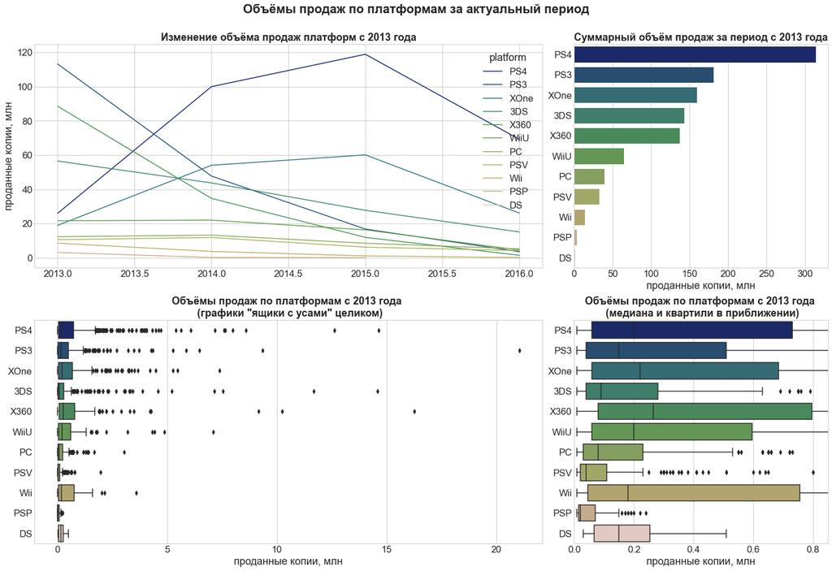

```python
fig = plt.figure(constrained_layout=True, figsize=(20, 13))
sns.set(font_scale=1.5)
plt.style.use('seaborn-whitegrid')
plt.suptitle('Объёмы продаж по платформам за актуальный период', fontweight='bold', y=1.05)
my_palette = 'gist_earth'

spec = gridspec.GridSpec(ncols=3, nrows=2, figure=fig)

total_sales_by_platform_actual = (df_actual.groupby('platform').agg({'total_sales':'sum'})
                                  .sort_values(by='total_sales', ascending=False)
                                  .reset_index().rename_axis(None, axis=1))

ax1 = fig.add_subplot(spec[0, :-1])
table_1 = (df_actual.groupby(['platform', 'year_of_release']).agg({'total_sales':'sum'})
               .reset_index().rename_axis(None, axis=1)
               .merge(total_sales_by_platform_actual, on='platform'))

sns.lineplot(data=table_1.sort_values(by='total_sales_y', ascending=False),
             x='year_of_release', y='total_sales_x', hue='platform', palette=my_palette)
plt.title('Изменение объёма продаж платформ c 2013 года', fontweight='bold')
plt.xlabel('')
plt.ylabel('проданные копии, млн')

ax2 = fig.add_subplot(spec[0, -1])
sns.barplot(data=total_sales_by_platform_actual.sort_values(by='total_sales', ascending=False),
            x='total_sales', y='platform', palette=my_palette)
plt.title('Суммарный объём продаж за период с 2013 года', fontweight='bold')
plt.xlabel('проданные копии, млн')
plt.ylabel('')

ax3 = fig.add_subplot(spec[1, :-1])
sns.boxplot(data=df_actual, x='total_sales', y='platform',
            order=total_sales_by_platform_actual['platform'], palette=my_palette)
plt.title('Объёмы продаж по платформам с 2013 года \n (графики "ящики с усами" целиком)', fontweight='bold')
plt.xlabel('проданные копии, млн')
plt.ylabel('')

ax4 = fig.add_subplot(spec[1, -1])
sns.boxplot(data=df_actual, x='total_sales', y='platform',
            order=total_sales_by_platform_actual['platform'], palette=my_palette)
plt.title('Объёмы продаж по платформам с 2013 года \n (медиана и квартили в приближении)', fontweight='bold')
plt.xlabel('проданные копии, млн')
plt.ylabel('')
plt.xlim([0, 0.85])

plt.show();
```

**Вывод**:

- на графиках "ящик с усами" мы можем отметить *более успешные в плане продаж платформы: X360, XOne, PS4, WiiU*
- у остальных платформ меньше разброса значений и в целом наиболее узкие "ящики", что говорит о более скромных результатах. У этих платформ реже имеются успешные по продажам игры, только единичные случаи преодолевают порог в 5 млн проданных копий

### Как оценки влияют на продажи

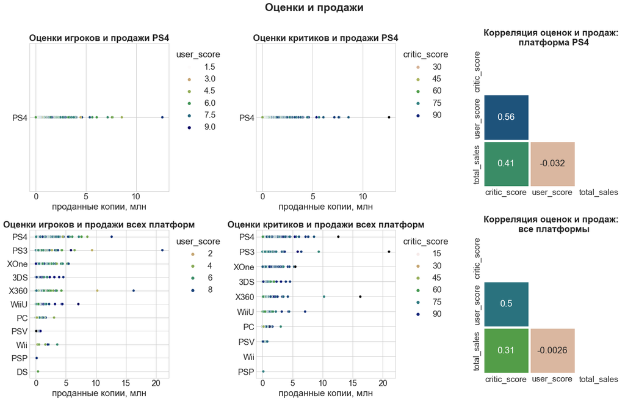

```python
plt.figure(figsize=(20, 13))
sns.set(font_scale=1.7)
plt.style.use('seaborn-whitegrid')
plt.suptitle('Оценки и продажи', fontweight='bold')

my_palette= 'gist_earth_r'

data = (df_actual.merge(total_sales_by_platform_actual, on='platform').sort_values(by='total_sales_y', ascending=False))
df_corr = df_actual[['name', 'critic_score', 'user_score', 'total_sales']]
df_corr_PS4 = df_actual.query('platform == "PS4"')[['name', 'critic_score', 'user_score', 'total_sales']]
corr_m = df_corr.corr()
corr_m_PS4 = df_corr_PS4.corr()

ax1 = plt.subplot(2, 3, 1)
ax=sns.scatterplot(data=df_actual.query('platform == "PS4"'), x='total_sales', y='platform', hue="user_score",
                 palette=my_palette)
sns.move_legend(ax, "upper left", bbox_to_anchor=(1, 1))
plt.title('Оценки игроков и продажи PS4', fontweight='bold')
plt.xlabel('проданные копии, млн')
plt.ylabel('')

ax2 = plt.subplot(2, 3, 2)
ax=sns.scatterplot(data=df_actual.query('platform == "PS4"'), x='total_sales', y='platform', hue="critic_score",
                    palette=my_palette)
sns.move_legend(ax, "upper left", bbox_to_anchor=(1, 1))
plt.title('Оценки критиков и продажи PS4', fontweight='bold')
plt.xlabel('проданные копии, млн')
plt.ylabel('')

ax3 = plt.subplot(2, 3, 3)
sns.heatmap(data=corr_m_PS4, square=True, annot=True, cmap=my_palette, linewidths=5, linecolor='white',
            mask=np.triu(corr_m), cbar=False, vmin=0, vmax=0.7, center= 0.3)
plt.title('Корреляция оценок и продаж: \n платформа PS4', fontweight='bold')
plt.xlabel('')
plt.ylabel('')


ax4 = plt.subplot(2, 3, 4)
ax=sns.scatterplot(data=data, x='total_sales_x', y='platform', hue="user_score",
                   palette=my_palette)
sns.move_legend(ax, "upper left", bbox_to_anchor=(1, 1))
plt.title('Оценки игроков и продажи всех платформ', fontweight='bold')
plt.xlabel('проданные копии, млн')
plt.ylabel('')

ax5 = plt.subplot(2, 3, 5)
ax=sns.scatterplot(data=data, x='total_sales_x', y='platform', hue="critic_score",
                   palette=my_palette)
sns.move_legend(ax, "upper left", bbox_to_anchor=(1, 1))
plt.title('Оценки критиков и продажи всех платформ', fontweight='bold')
plt.xlabel('проданные копии, млн')
plt.ylabel('')

ax6 = plt.subplot(2, 3, 6)
sns.heatmap(data=corr_m, square=True, annot=True, cmap=my_palette, linewidths=5, linecolor='white',
            mask=np.triu(corr_m), cbar=False, vmin=0, vmax=0.7, center=0.3)
plt.title('Корреляция оценок и продаж: \n все платформы', fontweight='bold')
plt.xlabel('')
plt.ylabel('')

plt.tight_layout()
plt.show();
```

**Вывод**:

- игры с низкими оценками чаще имеют небольшие продажи. Это можно заметить и на отдельно взятой платформе PS4, и на всех остальных платформах тоже. Бывают и исключения: некоторые игры с миллионными продажами имеют в итоге низкие оценки игроков.
- оценки игроков и критиков имеют разное значение
- гораздо большее *влияние на продажи оказывают оценки критиков*

### Распределение игр по жанрам

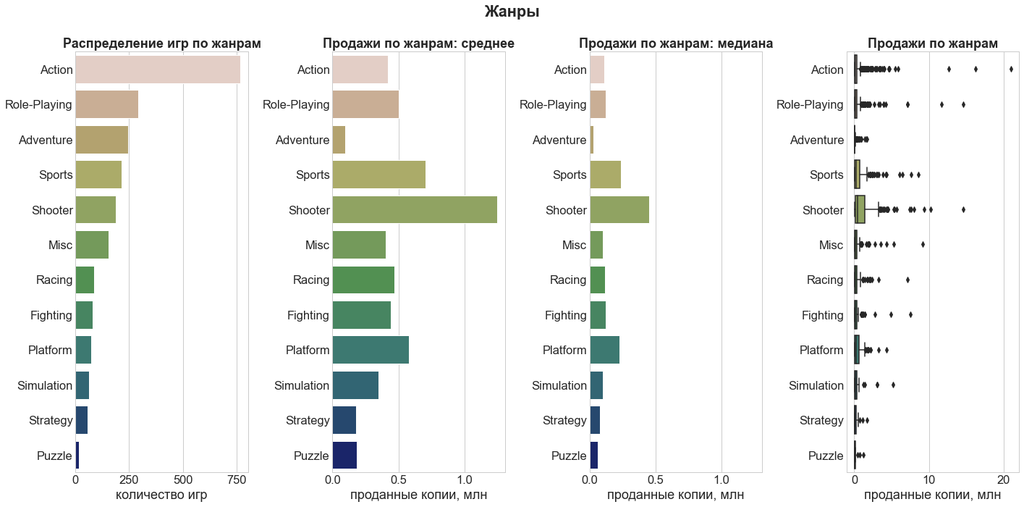

```python
plt.figure(figsize=(20, 10))
sns.set(font_scale=1.5)
plt.style.use('seaborn-whitegrid')
plt.suptitle('Жанры', fontweight='bold')

data = df_actual.groupby('genre').agg({'name':'count', 'total_sales':['mean','median']}).reset_index()
data.columns=['genre', 'games_cnt', 'sales_mean','sales_median']
data = data.sort_values(by='games_cnt', ascending=False)

ax1 = plt.subplot(1, 4, 1)
sns.barplot(data=data, x='games_cnt', y='genre', palette='gist_earth_r')
plt.title('Распределение игр по жанрам', fontweight='bold')
plt.xlabel('количество игр')
plt.ylabel('')

ax2 = plt.subplot(1, 4, 2)
sns.barplot(data=data, x='sales_mean', y='genre', palette='gist_earth_r')
plt.title('Продажи по жанрам: среднее', fontweight='bold')
plt.xlabel('проданные копии, млн')
plt.ylabel('')

ax3 = plt.subplot(1, 4, 3, sharex=ax2)
sns.barplot(data=data, x='sales_median', y='genre', palette='gist_earth_r')
plt.title('Продажи по жанрам: медиана', fontweight='bold')
plt.xlabel('проданные копии, млн')
plt.ylabel('')

ax4 = plt.subplot(1, 4, 4)
sns.boxplot(data=df_actual, x='total_sales', y='genre',
            order=data['genre'], palette='gist_earth_r')
plt.title('Продажи по жанрам', fontweight='bold')
plt.xlabel('проданные копии, млн')
plt.ylabel('')

plt.tight_layout()
plt.show();
```

**Вывод**:

- больше всего игр в жанре Action, но это не самое финансово успешное направление
- *самые прибыльные жанры: Shooter, Sports, Platform, Role-Playing*
- самые неудачные жанры в плане продаж: Adventure, Strategy, Puzzle
- среднее и медиана заметно отличаются, это происходит из-за выбросов - очень хорошо взлетевших проектов

## Портрет пользователя каждого региона

### Самые популярные платформы

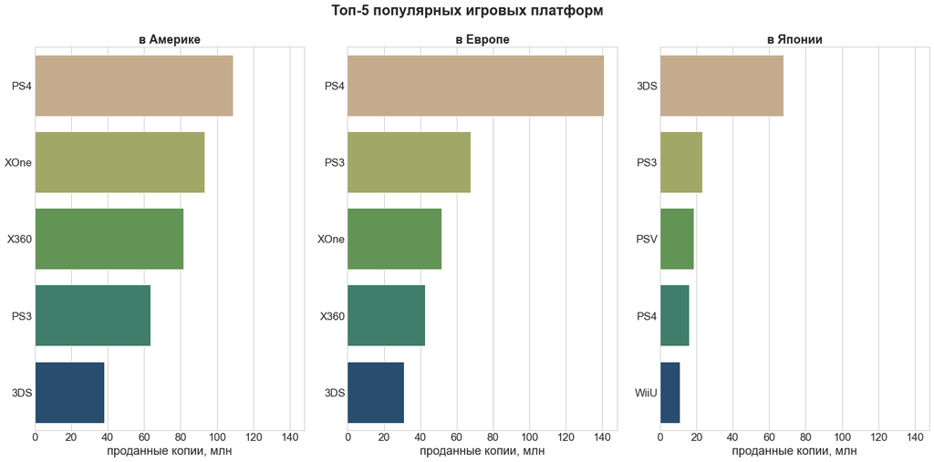

```python
plt.figure(figsize=(20, 10))
sns.set(font_scale=1.5)
plt.style.use('seaborn-whitegrid')
plt.suptitle('Топ-5 популярных игровых платформ', fontweight='bold')

data = (df_actual.groupby('platform', as_index=False)
                 .agg({'na_sales':'sum', 'eu_sales':'sum', 'jp_sales':'sum', 'total_sales':'sum'}))

ax1 = plt.subplot(1, 3, 1)
sns.barplot(data=data.sort_values(by='na_sales', ascending=False).head(), x='na_sales', y='platform',
            palette='gist_earth_r')
plt.title('в Америке', fontweight='bold')
plt.xlabel('проданные копии, млн')
plt.ylabel('')

ax2 = plt.subplot(1, 3, 2, sharex=ax1)
sns.barplot(data=data.sort_values(by='eu_sales', ascending=False).head(), x='eu_sales', y='platform',
            palette='gist_earth_r')
plt.title('в Европе', fontweight='bold')
plt.xlabel('проданные копии, млн')
plt.ylabel('')

ax3 = plt.subplot(1, 3, 3, sharex=ax1)
sns.barplot(data=data.sort_values(by='jp_sales', ascending=False).head(), x='jp_sales', y='platform',
            palette='gist_earth_r')
plt.title('в Японии', fontweight='bold')
plt.xlabel('проданные копии, млн')
plt.ylabel('')

plt.tight_layout()
plt.show();
```

**Вывод**:

- в каждом регионе свой топ-5 популярных игровых платформ
- предпочтения жителей Америки и Европы схожи, а вот топ-5 популярных платформ Японии отличается сильнее и включает в себя другие наименования

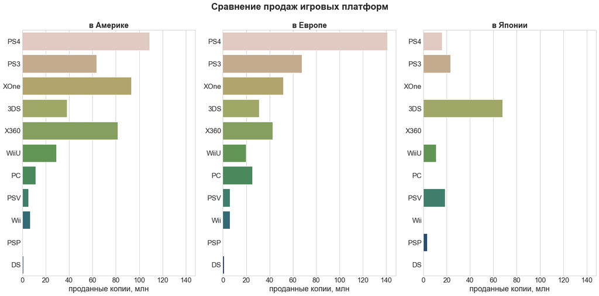

```python
plt.figure(figsize=(20, 10))
sns.set(font_scale=1.5)
plt.style.use('seaborn-whitegrid')
plt.suptitle('Сравнение продаж игровых платформ', fontweight='bold')

data = (df_actual.groupby('platform', as_index=False)
                 .agg({'na_sales':'sum', 'eu_sales':'sum', 'jp_sales':'sum', 'total_sales':'sum'})
                 .sort_values(by='total_sales', ascending=False))

ax1 = plt.subplot(1, 3, 1)
sns.barplot(data=data, x='na_sales', y='platform',
            palette='gist_earth_r')
plt.title('в Америке', fontweight='bold')
plt.xlabel('проданные копии, млн')
plt.ylabel('')

ax2 = plt.subplot(1, 3, 2, sharex=ax1)
sns.barplot(data=data, x='eu_sales', y='platform',
            palette='gist_earth_r')
plt.title('в Европе', fontweight='bold')
plt.xlabel('проданные копии, млн')
plt.ylabel('')

ax3 = plt.subplot(1, 3, 3, sharex=ax1)
sns.barplot(data=data, x='jp_sales', y='platform',
            palette='gist_earth_r')
plt.title('в Японии', fontweight='bold')
plt.xlabel('проданные копии, млн')
plt.ylabel('')

plt.tight_layout()
plt.show();
```

**Вывод**:

- на этом графике мы видим, как сильно отличается рынок Японии
- похоже, на общую сумму продаж сильнее оказывает влияние Европа: именно её график больше всего схож с расположением платформ по объёму продаж

### Самые популярные жанры

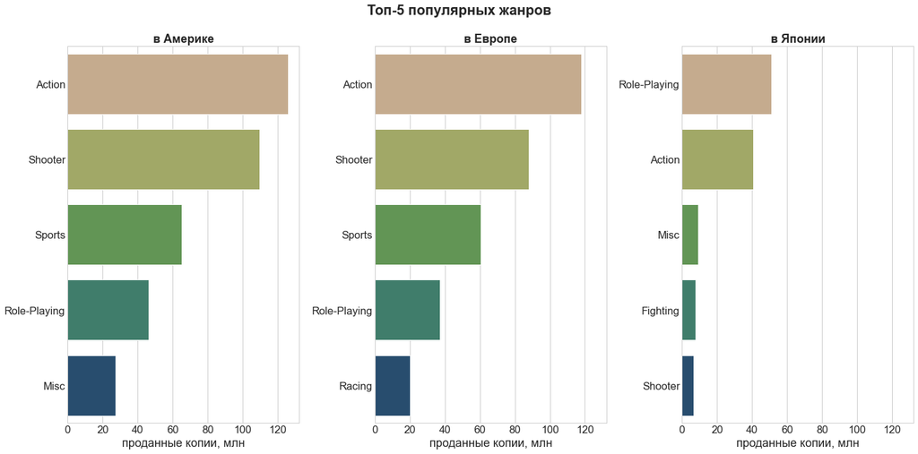

```python
plt.figure(figsize=(20, 10))
sns.set(font_scale=1.5)
plt.style.use('seaborn-whitegrid')
plt.suptitle('Топ-5 популярных жанров', fontweight='bold')

data = (df_actual.groupby('genre', as_index=False)
                 .agg({'na_sales':'sum', 'eu_sales':'sum', 'jp_sales':'sum', 'total_sales':'sum'}))

ax1 = plt.subplot(1, 3, 1)
sns.barplot(data=data.sort_values(by='na_sales', ascending=False).head(), x='na_sales', y='genre',
            palette='gist_earth_r')
plt.title('в Америке', fontweight='bold')
plt.xlabel('проданные копии, млн')
plt.ylabel('')

ax2 = plt.subplot(1, 3, 2, sharex=ax1)
sns.barplot(data=data.sort_values(by='eu_sales', ascending=False).head(), x='eu_sales', y='genre',
            palette='gist_earth_r')
plt.title('в Европе', fontweight='bold')
plt.xlabel('проданные копии, млн')
plt.ylabel('')

ax3 = plt.subplot(1, 3, 3, sharex=ax1)
sns.barplot(data=data.sort_values(by='jp_sales', ascending=False).head(), x='jp_sales', y='genre',
            palette='gist_earth_r')
plt.title('в Японии', fontweight='bold')
plt.xlabel('проданные копии, млн')
plt.ylabel('')

plt.tight_layout()
plt.show();
```

**Вывод**:

- снова мы наблюдаем схожесть в предпочтениях игроков из Америки и Европы (и здесь даже бОльшую, чем в платформах - из-за одинаковой расстановки четырёх из пяти самых популярных жанров)
- и снова наблюдаем другие наименования в любимых жанрах игроков из Японии
- Action и Role-Playing, однако, являются объединяющим элементом. В каждой бы части света ни находился игрок, скорее всего, эти два жанра имеют шансы ему понравиться

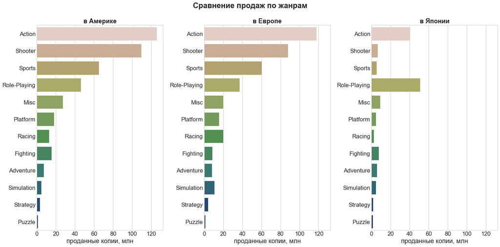

```python
plt.figure(figsize=(20, 10))
sns.set(font_scale=1.5)
plt.style.use('seaborn-whitegrid')
plt.suptitle('Сравнение продаж по жанрам', fontweight='bold')

data = (df_actual.groupby('genre', as_index=False)
                 .agg({'na_sales':'sum', 'eu_sales':'sum', 'jp_sales':'sum', 'total_sales':'sum'})
                 .sort_values(by='total_sales', ascending=False))

ax1 = plt.subplot(1, 3, 1)
sns.barplot(data=data, x='na_sales', y='genre',
            palette='gist_earth_r')
plt.title('в Америке', fontweight='bold')
plt.xlabel('проданные копии, млн')
plt.ylabel('')

ax2 = plt.subplot(1, 3, 2, sharex=ax1)
sns.barplot(data=data, x='eu_sales', y='genre',
            palette='gist_earth_r')
plt.title('в Европе', fontweight='bold')
plt.xlabel('проданные копии, млн')
plt.ylabel('')

ax3 = plt.subplot(1, 3, 3, sharex=ax1)
sns.barplot(data=data, x='jp_sales', y='genre',
            palette='gist_earth_r')
plt.title('в Японии', fontweight='bold')
plt.xlabel('проданные копии, млн')
plt.ylabel('')

plt.tight_layout()
plt.show();
```

**Вывод**:

- на этом графике мы видим, как Япония "вытащила" жанр Role-Playing на четвёртое место
- Action популярен везде
- Shooter и Sports недооценены в Японии
- остальные жанры "дышат друг другу в спину"

### Влияет ли рейтинг ESRB на продажи в отдельном регионе

Для начала посмотрим, сколько у нас категорий рейтинга в данных за актуальный период, сколько игр и каковы продажи:

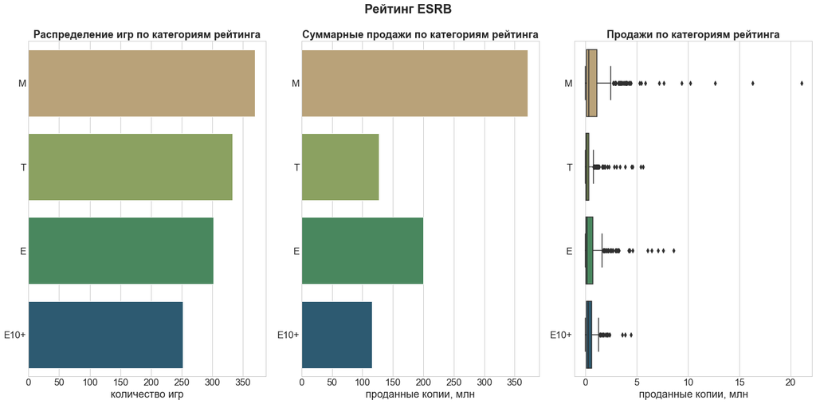

```python
plt.figure(figsize=(20, 10))
sns.set(font_scale=1.5)
plt.style.use('seaborn-whitegrid')
plt.suptitle('Рейтинг ESRB', fontweight='bold')

data = (df_actual.groupby('rating').agg({'name':'count', 'total_sales': 'sum'})
                 .sort_values(by='name', ascending=False).reset_index().rename_axis(None, axis=1))
data.columns=['rating', 'games_cnt','total_sales']

ax1 = plt.subplot(1, 3, 1)
sns.barplot(data=data, x='games_cnt', y='rating', palette='gist_earth_r')
plt.title('Распределение игр по категориям рейтинга', fontweight='bold')
plt.xlabel('количество игр')
plt.ylabel('')

ax2 = plt.subplot(1, 3, 2)
sns.barplot(data=data, x='total_sales', y='rating', palette='gist_earth_r')
plt.title('Суммарные продажи по категориям рейтинга', fontweight='bold')
plt.xlabel('проданные копии, млн')
plt.ylabel('')

ax3 = plt.subplot(1, 3, 3)
sns.boxplot(data=df_actual, x='total_sales', y='rating',
            order=data['rating'], palette='gist_earth_r')
plt.title('Продажи по категориям рейтинга', fontweight='bold')
plt.xlabel('проданные копии, млн')
plt.ylabel('')

plt.tight_layout()
plt.show();
```

**Вывод**:

- в данных за акутальный период у нас 4 категории:
  - «M» («Mature») — «Для взрослых»
  - «T» («Teen») — «Подросткам»
  - «E» («Everyone») — «Для всех»
  - «E10+» («Everyone 10 and older»)
- количество игр разное в этих категориях, но без сильных перепадов
- лучше всего продаются игры для взрослых (М) и для всех (Е)

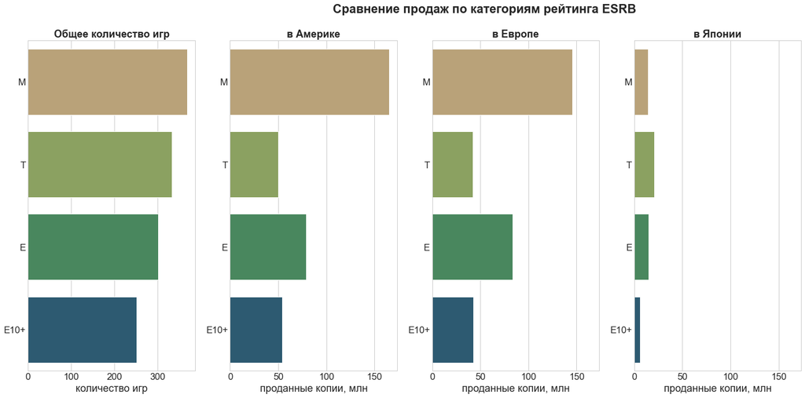

```python
plt.figure(figsize=(20, 10))
sns.set(font_scale=1.5)
plt.style.use('seaborn-whitegrid')
plt.suptitle('Сравнение продаж по категориям рейтинга ESRB', fontweight='bold',  x=0.6)

data = (df_actual.groupby('rating', as_index=False)
                 .agg({'name':'count','na_sales':'sum', 'eu_sales':'sum', 'jp_sales':'sum', 'total_sales':'sum'})
                 .sort_values(by='name', ascending=False))

ax1 = plt.subplot(1, 4, 1)
sns.barplot(data=data, x='name', y='rating', palette='gist_earth_r')
plt.title('Общее количество игр', fontweight='bold')
plt.xlabel('количество игр')
plt.ylabel('')

ax2 = plt.subplot(1, 4, 2)
sns.barplot(data=data, x='na_sales', y='rating',
            palette='gist_earth_r')
plt.title('в Америке', fontweight='bold')
plt.xlabel('проданные копии, млн')
plt.ylabel('')

ax3 = plt.subplot(1, 4, 3, sharex=ax2)
sns.barplot(data=data, x='eu_sales', y='rating',
            palette='gist_earth_r')
plt.title('в Европе', fontweight='bold')
plt.xlabel('проданные копии, млн')
plt.ylabel('')

ax4 = plt.subplot(1, 4, 4, sharex=ax2)
sns.barplot(data=data, x='jp_sales', y='rating',
            palette='gist_earth_r')
plt.title('в Японии', fontweight='bold')
plt.xlabel('проданные копии, млн')
plt.ylabel('')

plt.tight_layout()
plt.show();
```

**Вывод**:

- да, рейтинг ESRB влияет на продажи в регионах
- в Америке и в Европе более популярны игры категорий М (для взрослых) и Е (для всех), а менее популярны игры категории Т (для подростков)
- в Японии другая ситуация: практически нет разницы между категориями М, Т, Е (при этом T имеет показатели даже чуть получше своих соседей), а хуже всего показатели продаж у категории Е10+

## Проверка гипотез

Проверим пару гипотез.

**1. Гипотеза: средние пользовательские рейтинги платформ Xbox One и PC одинаковые**

Сформулируем нулевую гипотезу:

- средние пользовательские рейтинги платформ Xbox One и PC равны

Альтернативная гипотеза:

- средние рейтинги не равны

Это двусторонняя альтернативная гипотеза.

Для проверки гипотез нам нужно отобрать данные без пропусков:

```python
df_hyp = df_actual
df_hyp.dropna(subset=['user_score'], inplace=True)
```

Посмотрим, сколько у нас строк:

```python
len(df_hyp['user_score'])
```

```
1192
```

Посмотрим на размер выборок:

```python
x_one = df_hyp.query('platform == "XOne"')
print(f'Размер выборки для платформы Xbox One: {len(x_one)}')
pc = df_hyp.query('platform == "PC"')
print(f'Размер выборки для платформы PC: {len(pc)}')
```

```
Размер выборки для платформы Xbox One: 182
Размер выборки для платформы PC: 155
```

Поскольку мы работаем с гипотезами о равенстве средних двух генеральных совокупностей, спользуем метод scipy.stats.ttest_ind, куда в качестве аргументов передадим массивы, содержащие выборки для двух платформ. Размеры выборок близки, так что параметр equal_var=False нам использовать не придётся, он автоматически будет equal_var=True.

```python
alpha = 0.05

results = st.ttest_ind(x_one['user_score'], pc['user_score'])

print('p-значение:', results.pvalue)

if results.pvalue < alpha:
    print('Отвергаем нулевую гипотезу')
else:
    print('Не получилось отвергнуть нулевую гипотезу')
```

```
p-значение: 0.14012658403611647
Не получилось отвергнуть нулевую гипотезу
```

**Вывод**:

- не получилось отвергнуть нулевую гипотезу, значит, статистически значимых различий в пользовательских оценках этих платформ нет

**2. Гипотеза: средние пользовательские рейтинги жанров Action (англ. «действие», экшен-игры) и Sports (англ. «спортивные соревнования») разные**

Сформулируем нулевую гипотезу:

- средние пользовательские рейтинги жанров Action и Sports равны

Альтернативная гипотеза:

- средние рейтинги не равны

Это снова двусторонняя альтернативная гипотеза. Хотя в этот раз нас интересует, разные ли средние значения, нулевую гипотезу мы всё равно формулируем так, чтобы использовать равенство.

Посмотрим на размер выборок:

```python
action = df_hyp.query('genre == "Action"')
print(f'Размер выборки для жанра Action: {len(action)}')
sports = df_hyp.query('genre == "Sports"')
print(f'Размер выборки для жанра Sports: {len(sports)}')
```

```
Размер выборки для жанра Action: 389
Размер выборки для жанра Sports: 160
```

Мы снова работаем с гипотезами о равенстве средних двух генеральных совокупностей, поэтому снова спользуем метод scipy.stats.ttest_ind, но для этой гипотезы используем параметр equal_var=False, потому что размеры выборок заметно отличаются.

```python
alpha = 0.05

results = st.ttest_ind(action['user_score'], sports['user_score'], equal_var=False)

print('p-значение:', results.pvalue)

if results.pvalue < alpha:
    print('Отвергаем нулевую гипотезу')
else:
    print('Не получилось отвергнуть нулевую гипотезу')
```

```
p-значение: 1.4460039700704315e-20
Отвергаем нулевую гипотезу
```

**Вывод**:

- в результате теста нулевая гипотеза отвергнута, значит, средние пользовательские рейтинги двух жанров скорее разные и при сборе бОльших данных тоже будут отличаться.

**Дополнительно визуализируем**, каковы наши имеющиеся данные, на которых мы проводили статистические тесты:

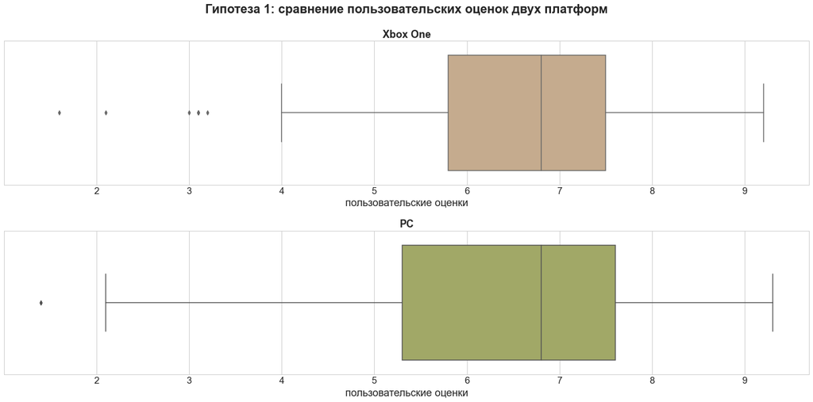

```python
plt.figure(figsize=(20, 10))
sns.set(font_scale=1.5)
plt.style.use('seaborn-whitegrid')
plt.suptitle('Гипотеза 1: сравнение пользовательских оценок двух платформ', fontweight='bold')

ax1 = plt.subplot(2, 1, 1)
sns.boxplot(x=x_one['user_score'], color='#ceab85')
plt.title('Xbox One', fontweight='bold')
plt.xlabel('пользовательские оценки')

ax2 = plt.subplot(2, 1, 2, sharex=ax1)
sns.boxplot(x=pc['user_score'], color='#aab35c')
plt.title('PC', fontweight='bold')
plt.xlabel('пользовательские оценки')

plt.tight_layout()
plt.show();
```

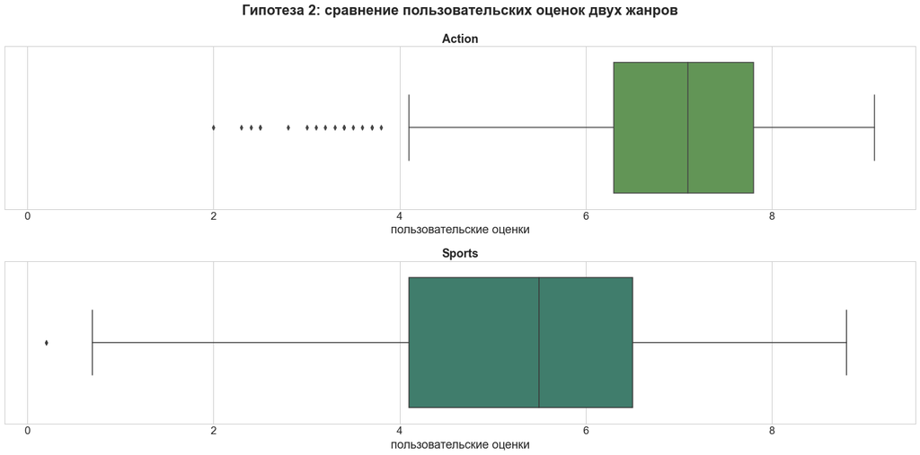

```python
plt.figure(figsize=(20, 10))
sns.set(font_scale=1.5)
plt.style.use('seaborn-whitegrid')
plt.suptitle('Гипотеза 2: сравнение пользовательских оценок двух жанров', fontweight='bold')

ax1 = plt.subplot(2, 1, 1)
sns.boxplot(x=action['user_score'], color='#5ba04b')
plt.title('Action', fontweight='bold')
plt.xlabel('пользовательские оценки')

ax2 = plt.subplot(2, 1, 2, sharex=ax1)
sns.boxplot(x=sports['user_score'], color='#368770')
plt.title('Sports', fontweight='bold')
plt.xlabel('пользовательские оценки')

plt.tight_layout()
plt.show();
```

## Выводы

Для исследования были использованы **данные** из 16715 строк и 11 столбцов.

В процессе **предобработки** были выполнены следующие действия:

- названия столбцов приведены к нижнему регистру
- данные в столбце user_score приведены к числовому формату
- записана расшифровка обозначений из столбца rating
- подробно рассмотрены пропуски, разобраны возможные причины их появления, визуализированы отличия игр с оценками и без
- в данные добавлен столбец total_sales - суммарные продажи во всех регионах

**Исследовательский анализ данных**

**1. Сколько игр выпускалось в разные годы**

- мы видим, что *количество выпускаемых игр с годами сильно менялось*: плавное увеличение количества игр с середины 1990-х пришло к пику в 2008-2009 годах (когда выходило по 1400 игр в год), и затем сменилось падением. За последнее время рынок стабилизировался на отметке 500-600 выпускаемых игр в год
- для нашего исследования данные 1980-1990х годов не особо актуальны

**2. Как менялись продажи по платформам**

- *с течением времени разные платформы выходили на первый план по объёмам продаж*: то PS, то PS2, то Wii были лидерами рынка
- можно отметить *характерный период, за который появляются и исчезают лидеры рынка - это примерно 5 лет*
- при этом отметим, что с 2005 года конкуренция усилилась: если раньше среди крупных платформ был один явный лидер, то теперь успешные платформы существуют параллельно друг с другом, имея сопоставимые объёмы продаж
- *за последние годы по объёму продаж вперёд вышли PS4, PS3 и XOne*

**3. Актуальный период** Поскольку ранее мы выяснили, что в отрасли сменяются лидеры примерно раз в 5 лет, можно остановиться на этом периоде как актуальном и выделить данные за период с 2012 года.

*Но* сами наши данные показывают, что в последние годы характер изменений стал другим, а лидеры последних лет начали свой рост с 2013 года. Поэтому актуальнее для прогноза выделить данные *с 2013 года*: будет и не много (чтобы не захватить отжившие тренды), и не мало (чтобы данных для анализа и прогнозов было достаточно).

- на графиках "ящик с усами" мы можем отметить *более успешные в плане продаж платформы: X360, XOne, PS4, WiiU*
- у остальных платформ меньше разброса значений и в целом наиболее узкие "ящики", что говорит о более скромных результатах. У этих платформ реже имеются успешные по продажам игры, только единичные случаи преодолевают порог в 5 млн проданных копий

**4. Как оценки влияют на продажи**

- *игры с низкими оценками чаще имеют небольшие продажи*. Это можно заметить и на отдельно взятой платформе PS4, и на всех остальных платформах тоже. Бывают и исключения: некоторые игры с миллионными продажами имеют в итоге низкие оценки игроков.
- оценки игроков и критиков имеют разное значение
- гораздо большее *влияние на продажи оказывают оценки критиков*

**5. Распределение игр по жанрам**

- больше всего игр в жанре Action, но это не самое финансово успешное направление
- *самые прибыльные жанры: Shooter, Sports, Platform, Role-Playing*
- самые неудачные жанры в плане продаж: Adventure, Strategy, Puzzle

**Портрет пользователя каждого региона**

**1. Самые популярные платформы**

- в каждом регионе свой топ-5 популярных игровых платформ
- предпочтения жителей Америки и Европы схожи, а вот топ-5 популярных платформ Японии отличается сильнее и включает в себя другие наименования
- похоже, на общую сумму продаж сильнее оказывает влияние Европа: именно её график больше всего схож с расположением платформ по объёму продаж

**2. Самые популярные жанры**

- снова мы наблюдаем схожесть в предпочтениях игроков из Америки и Европы (и здесь даже бОльшую, чем в платформах - из-за одинаковой расстановки четырёх из пяти самых популярных жанров)
- и снова наблюдаем другие наименования в любимых жанрах игроков из Японии
- Action и Role-Playing, однако, являются объединяющим элементом. В каждой бы части света ни находился игрок, скорее всего, эти два жанра имеют шансы ему понравиться

**3. Рейтинг ESRB**

- в данных за акутальный период у нас 4 категории:
  - «M» («Mature») — «Для взрослых»
  - «T» («Teen») — «Подросткам»
  - «E» («Everyone») — «Для всех»
  - «E10+» («Everyone 10 and older»)
- количество игр разное в этих категориях, но без сильных перепадов
- лучше всего продаются игры для взрослых (М) и для всех (Е)
- рейтинг ESRB влияет на продажи в регионах
- в Америке и в Европе более популярны игры категорий М (для взрослых) и Е (для всех), а менее популярны игры категории Т (для подростков)
- в Японии другая ситуация: практически нет разницы между категориями М, Т, Е (причём у T показатели даже чуть получше других), а хуже всего показатели продаж у категории Е10+

**Проверка гипотез**

**1. Гипотеза: средние пользовательские рейтинги платформ Xbox One и PC одинаковые**

- не получилось отвергнуть нулевую гипотезу, значит, статистически значимых различий в пользовательских оценках этих платформ нет

**2. Гипотеза: средние пользовательские рейтинги жанров Action (англ. «действие», экшен-игры) и Sports (англ. «спортивные соревнования») разные**

- в результате теста нулевая гипотеза отвергнута, значит, средние пользовательские рейтинги двух жанров скорее разные и при сборе бОльших данных тоже будут отличаться.

**Дополнение/Call To Action**: поскольку и для всего исследования, и для раздела с проверками статистических гипотез важны оценки пользователей, хотелось бы при сборе сведений минимизировать наличие пропусков, если это возможно.

Исследование выполнила: аналитик данных Малахова Наталья

Мой телеграм-канал: [Дневник аналитика](https://t.me/diary_musician_analyst)

Портфолио: [GitHub](https://github.com/Malakhova-Natalya)

Спасибо за внимание!